# Preliminary Results

Zoey Werbin

4/10/2020

## Overview

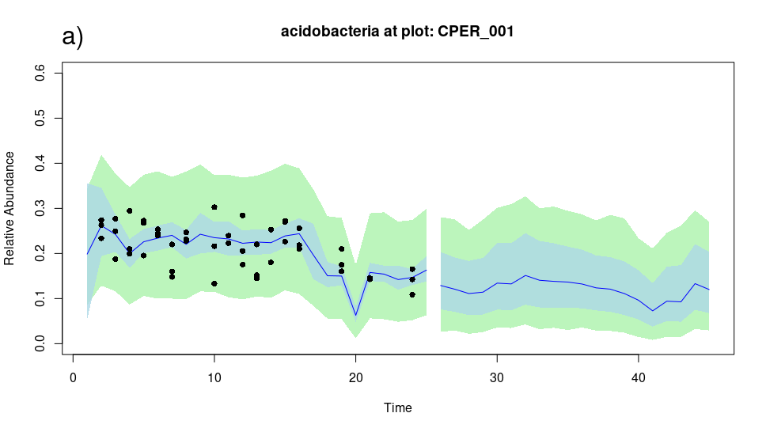

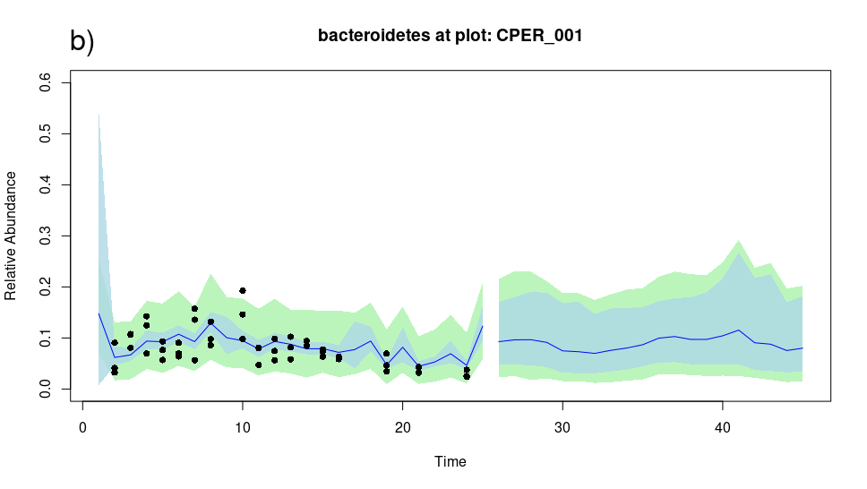

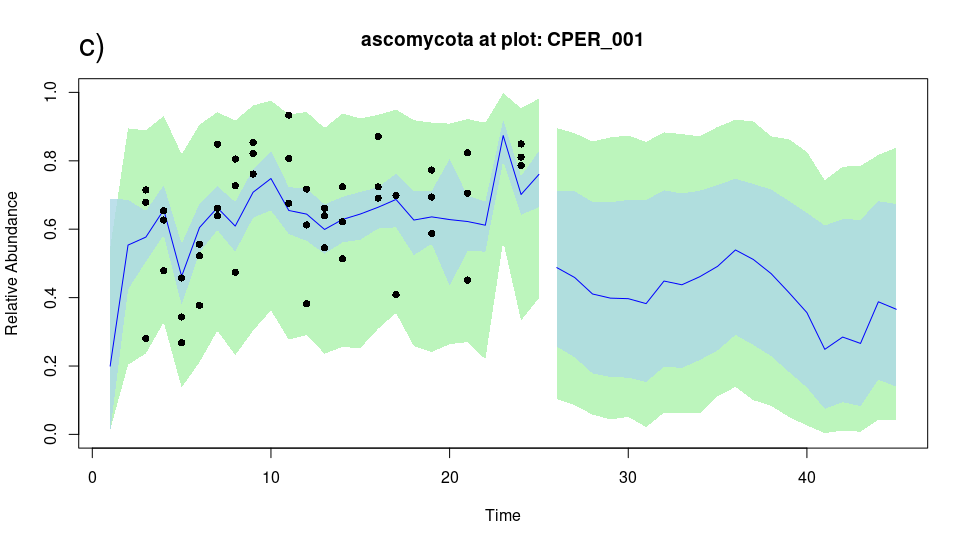

## Spatiotemporal variability

We hypothesized that spatial variability would eclipse temporal variability. To test this, we included random effects (with a mean of 0) to capture variation specific to plots, sites, and time points. The standard deviation of these random effects was estimated using 1000 Markov Chain Monte Carlo samples from the posterior densities. The these samples were drawn for ten bacterial phyla and ten fungal phyla (resulting in 10000 draws per parameter), and the resulting distributions are visible in Figure 2. Variability among the five study sites was much larger than variability among plots or variability among time points.

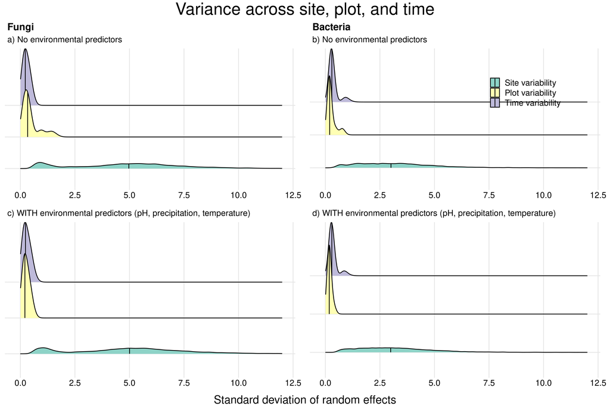

**Figure 2.** Ridge plots showing the density of 10,000 posterior samples of standard deviations of time random effects, plot random effects, and site random effects. a) Sample densities for ten fungal phyla for models in which environmental predictors were excluded. b) Sample densities for ten bacterial phyla for models in which environmental predictors were excluded. c) Sample densities for ten fungal phyla for models in which pH, temperature, and precipitation were included. d) Sample densities for ten bacterial phyla for models in which pH, temperature, and precipitation were included. For all four cases, variability among sites is larger than among-plot or among-time variability.

## Sensitivity to environmental factors

Our hypothesis that bacteria are more sensitive then fungi to environmental conditions is supported by our results, but our sample size is relatively low - 10 bacterial and 10 fungal phyla. The effect of temperature was significant (e.g. 95% confidence interval did not overlap with zero) for 3 fungal groups (Fig 3a) and 4 bacterial groups (Fig 3d). The effect of precipitation was significant for 2 fungal groups (Fig 3b) and 3 bacterial groups (Fig 3e). The effect of pH was significant for 0 fungal groups (Fig 3c) and five bacterial groups (Fig 3f). Overall, 9 bacterial groups were sensitive to at least one environmental factor, while only 5 fungal groups were sensitive to at least one environmental factor.

### Fungi

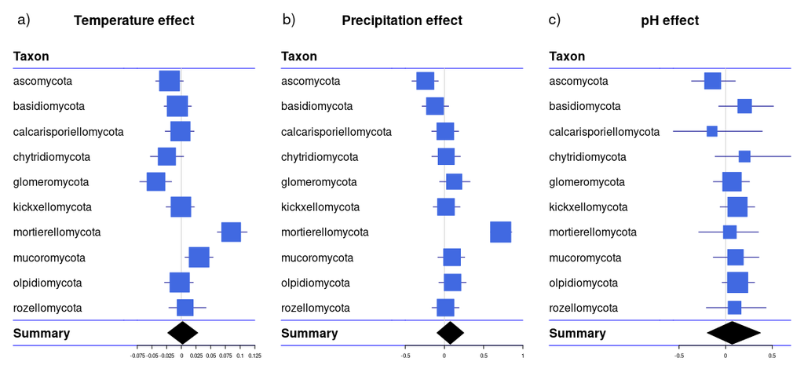